# Homework (Chapter 8)

#### 변수 age, log(bili)를 포함한 Cox 모형 적합 후 패턴변화가 줄어듬.

```r
# age, albumin
fit <- coxph(Surv(time,censor)~age+albumin,data=pbc)
summary(fit)
```

```
## Call:
## coxph(formula = Surv(time, censor) ~ age + albumin, data = pbc)
##
##   n= 418, number of events= 161
##
##              coef exp(coef)  se(coef)      z Pr(>|z|)
## age      0.032664  1.033204  0.008014  4.076 4.58e-05 ***
## albumin -1.428794  0.239598  0.182547 -7.827 5.00e-15 ***
## ---
## Signif. codes:  0 '***' 0.001 '**' 0.01 '*' 0.05 '.' 0.1 ' ' 1
##
##         exp(coef) exp(-coef) lower .95 upper .95
## age        1.0332     0.9679    1.0171    1.0496
## albumin    0.2396     4.1737    0.1675    0.3427
##
## Concordance= 0.721  (se = 0.021 )
## Likelihood ratio test= 81.15  on 2 df,   p=<2e-16
## Wald test            = 87.87  on 2 df,   p=<2e-16
## Score (logrank) test = 88.64  on 2 df,   p=<2e-16
```

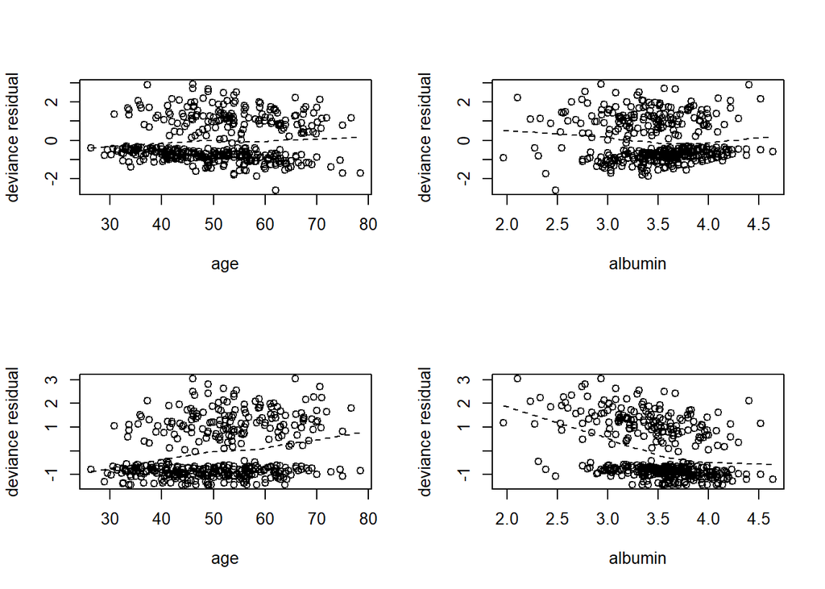

```r
r <- resid(fit,data=pbc,type="deviance")
par(mfrow=c(2,2))
plot(age,r,xlab="age",ylab="deviance residual")
lines(lowess(age,r,iter=0),lty=2)
plot(albumin,r,xlab="albumin",ylab="deviance residual")
lines(lowess(albumin,r,iter=0),lty=2)
plot(age,r1,xlab="age",ylab="deviance residual")
lines(lowess(age,r1,iter=0),lty=2)
plot(albumin,r1,xlab="albumin",ylab="deviance residual")
lines(lowess(albumin,r1,iter=0),lty=2)
```

```r
par(mfrow=c(1,1))
```

#### 변수 age, albumin을 포함한 Cox 모형 적합 후 패턴변화가 줄어듬.

```r
# age, log(protime)
fit <- coxph(Surv(time,censor)~age+log(protime),data=pbc)
summary(fit)
```

```
## Call:
## coxph(formula = Surv(time, censor) ~ age + log(protime), data = pbc)
##
##   n= 416, number of events= 160
##    (2 observations deleted due to missingness)
##
##                  coef exp(coef) se(coef)     z Pr(>|z|)
## age           0.03761   1.03833  0.00768 4.897 9.72e-07 ***
## log(protime)  3.88156  48.49980  0.59227 6.554 5.61e-11 ***
## ---
## Signif. codes:  0 '***' 0.001 '**' 0.01 '*' 0.05 '.' 0.1 ' ' 1
##
##              exp(coef) exp(-coef) lower .95 upper .95
## age              1.038    0.96309     1.023     1.054
## log(protime)    48.500    0.02062    15.192   154.838
##
## Concordance= 0.715  (se = 0.022 )
## Likelihood ratio test= 56.93  on 2 df,   p=4e-13
## Wald test            = 67.19  on 2 df,   p=3e-15
## Score (logrank) test = 68.43  on 2 df,   p=1e-15
```

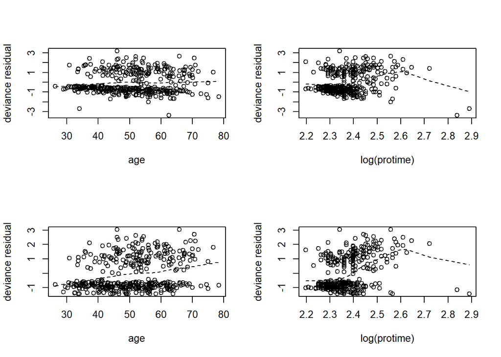

```r
r <- resid(fit,data=pbc,type="deviance")
par(mfrow=c(2,2))
plot(age[is.na(log(protime))!=TRUE],r,xlab="age",ylab="deviance residual")
lines(lowess(age[is.na(log(protime))!=TRUE],r,iter=0),lty=2)
plot(log(protime)[is.na(log(protime))!=TRUE],r,xlab="log(protime)",ylab="deviance residual")
lines(lowess(log(protime)[is.na(log(protime))!=TRUE],r,iter=0),lty=2)
plot(age[is.na(log(protime))!=TRUE],r1[is.na(log(protime))!=TRUE],xlab="age",ylab="deviance residual")
lines(lowess(age[is.na(log(protime))!=TRUE],r1[is.na(log(protime))!=TRUE],iter=0),lty=2)
plot(log(protime)[is.na(log(protime))!=TRUE],r1[is.na(log(protime))!=TRUE],xlab="log(protime)",ylab="deviance residual")
lines(lowess(log(protime)[is.na(log(protime))!=TRUE],r1[is.na(log(protime))!=TRUE],iter=0),lty=2)
```

```r
par(mfrow=c(1,1))
```

#### 변수 age, log(protime)을 포함한 Cox 모형 적합 후 패턴변화가 줄어듬.

```r
# age, edema
fit <- coxph(Surv(time,censor)~age+edema,data=pbc)
summary(fit)
```

```
## Call:
## coxph(formula = Surv(time, censor) ~ age + edema, data = pbc)
##
##   n= 418, number of events= 161
##
##           coef exp(coef) se(coef)     z Pr(>|z|)
## age   0.031607  1.032112 0.007485 4.223 2.41e-05 ***
## edema 2.144844  8.540706 0.252135 8.507  < 2e-16 ***
## ---
## Signif. codes:  0 '***' 0.001 '**' 0.01 '*' 0.05 '.' 0.1 ' ' 1
##
##       exp(coef) exp(-coef) lower .95 upper .95
## age       1.032     0.9689     1.017     1.047
## edema     8.541     0.1171     5.210    13.999
##
## Concordance= 0.682  (se = 0.024 )
## Likelihood ratio test= 78.98  on 2 df,   p=<2e-16
## Wald test            = 98.73  on 2 df,   p=<2e-16
## Score (logrank) test = 117.9  on 2 df,   p=<2e-16
```

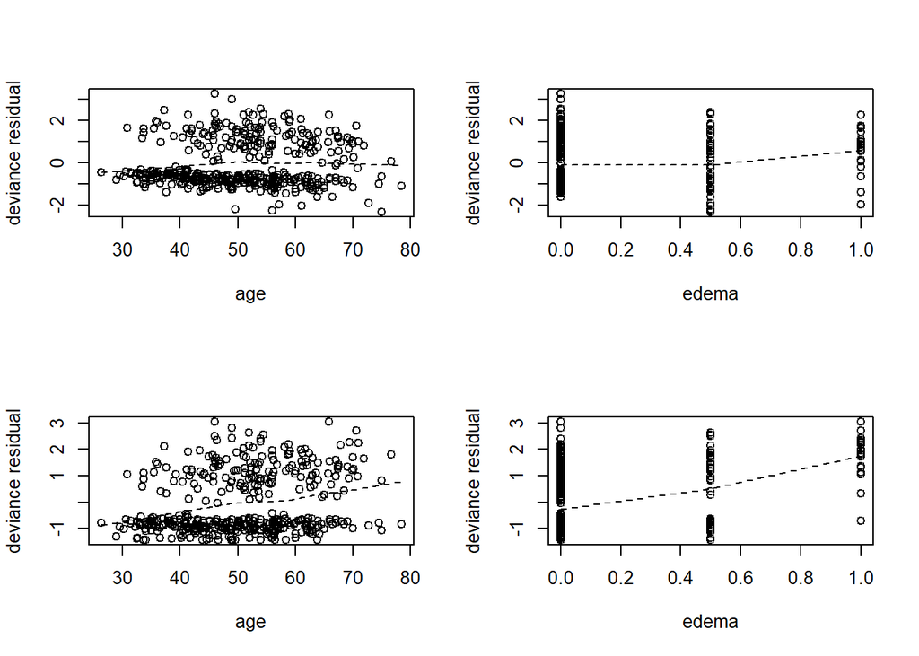

```r
r <- resid(fit,data=pbc,type="deviance")
par(mfrow=c(2,2))
plot(age,r,xlab="age",ylab="deviance residual")
lines(lowess(age,r,iter=0),lty=2)
plot(edema,r,xlab="edema",ylab="deviance residual")
lines(lowess(edema,r,iter=0),lty=2)
plot(age,r1,xlab="age",ylab="deviance residual")
lines(lowess(age,r1,iter=0),lty=2)
plot(edema,r1,xlab="edema",ylab="deviance residual")
lines(lowess(edema,r1,iter=0),lty=2)
```

```r
par(mfrow=c(1,1))
```

#### 변수 age, edema를 포함한 Cox 모형 적합 후 패턴변화가 줄어듬.

```r
# log(bili), albumin
fit <- coxph(Surv(time,censor)~log(bili)+albumin,data=pbc)
summary(fit)
```

```
## Call:
## coxph(formula = Surv(time, censor) ~ log(bili) + albumin, data = pbc)
##
##   n= 418, number of events= 161
##
##               coef exp(coef) se(coef)      z Pr(>|z|)
## log(bili)  0.89394   2.44475  0.08075 11.071  < 2e-16 ***
## albumin   -1.09951   0.33303  0.19782 -5.558 2.73e-08 ***
## ---
## Signif. codes:  0 '***' 0.001 '**' 0.01 '*' 0.05 '.' 0.1 ' ' 1
##
##           exp(coef) exp(-coef) lower .95 upper .95
## log(bili)     2.445      0.409     2.087    2.8640
## albumin       0.333      3.003     0.226    0.4908
##
## Concordance= 0.8  (se = 0.018 )
## Likelihood ratio test= 182.9  on 2 df,   p=<2e-16
## Wald test            = 186.8  on 2 df,   p=<2e-16
## Score (logrank) test = 216.1  on 2 df,   p=<2e-16
```

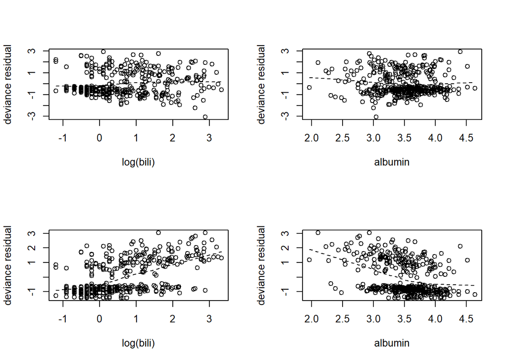

```r
r <- resid(fit,data=pbc,type="deviance")
par(mfrow=c(2,2))
plot(log(bili),r,xlab="log(bili)",ylab="deviance residual")
lines(lowess(log(bili),r,iter=0),lty=2)
plot(albumin,r,xlab="albumin",ylab="deviance residual")
lines(lowess(albumin,r,iter=0),lty=2)
plot(log(bili),r1,xlab="log(bili)",ylab="deviance residual")
lines(lowess(log(bili),r1,iter=0),lty=2)
plot(albumin,r1,xlab="albumin",ylab="deviance residual")
lines(lowess(albumin,r1,iter=0),lty=2)
```

```r
par(mfrow=c(1,1))
```

#### 변수 log(bili), albumin을 포함한 Cox 모형 적합 후 패턴변화가 줄어듬.

```r
# log(bili), log(protime)
fit <- coxph(Surv(time,censor)~log(bili)+log(protime),data=pbc)
summary(fit)
```

```
## Call:
## coxph(formula = Surv(time, censor) ~ log(bili) + log(protime),
##     data = pbc)
##
##   n= 416, number of events= 160
##    (2 observations deleted due to missingness)
##
##                  coef exp(coef) se(coef)      z Pr(>|z|)
## log(bili)     0.93059   2.53601  0.07962 11.689  < 2e-16 ***
## log(protime)  2.89057  18.00362  0.65967  4.382 1.18e-05 ***
## ---
## Signif. codes:  0 '***' 0.001 '**' 0.01 '*' 0.05 '.' 0.1 ' ' 1
##
##              exp(coef) exp(-coef) lower .95 upper .95
## log(bili)        2.536    0.39432     2.170     2.964
## log(protime)    18.004    0.05554     4.941    65.595
##
## Concordance= 0.795  (se = 0.018 )
## Likelihood ratio test= 165.4  on 2 df,   p=<2e-16
## Wald test            = 173.8  on 2 df,   p=<2e-16
## Score (logrank) test = 204.6  on 2 df,   p=<2e-16
```

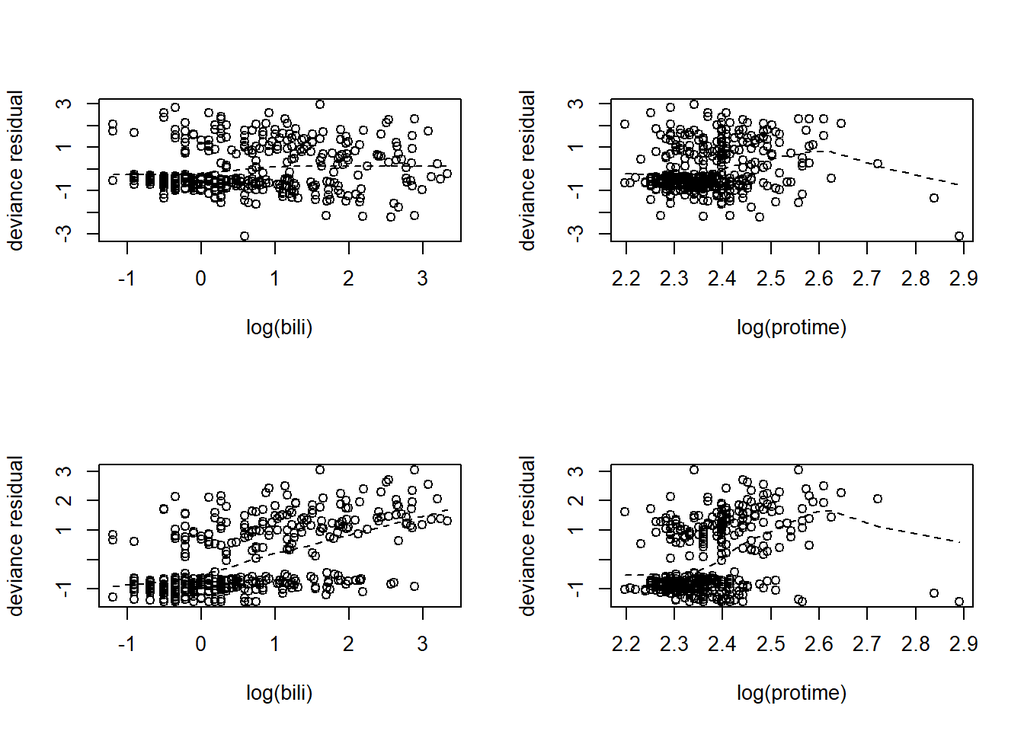

```r
r <- resid(fit,data=pbc,type="deviance")
par(mfrow=c(2,2))
plot(log(bili)[is.na(log(protime))!=TRUE],r,xlab="log(bili)",ylab="deviance residual")
lines(lowess(log(bili)[is.na(log(protime))!=TRUE],r,iter=0),lty=2)
plot(log(protime)[is.na(log(protime))!=TRUE],r,xlab="log(protime)",ylab="deviance residual")
lines(lowess(log(protime)[is.na(log(protime))!=TRUE],r,iter=0),lty=2)
plot(log(bili)[is.na(log(protime))!=TRUE],r1[is.na(log(protime))!=TRUE],xlab="log(bili)",ylab="deviance residual")
lines(lowess(log(bili)[is.na(log(protime))!=TRUE],r1[is.na(log(protime))!=TRUE],iter=0),lty=2)
plot(log(protime)[is.na(log(protime))!=TRUE],r1[is.na(log(protime))!=TRUE],xlab="log(protime)",ylab="deviance residual")
lines(lowess(log(protime)[is.na(log(protime))!=TRUE],r1[is.na(log(protime))!=TRUE],iter=0),lty=2)
```

```r
par(mfrow=c(1,1))
```

#### 변수 log(bili), log(protime)을 포함한 Cox 모형 적합 후 패턴변화가 줄어듬.

```r
# log(bili), edema
fit <- coxph(Surv(time,censor)~log(bili)+edema,data=pbc)
summary(fit)
```

```
## Call:
## coxph(formula = Surv(time, censor) ~ log(bili) + edema, data = pbc)
##
##   n= 418, number of events= 161
##
##              coef exp(coef) se(coef)     z Pr(>|z|)
## log(bili) 0.89547   2.44849  0.08069 11.10  < 2e-16 ***
## edema     1.43450   4.19755  0.24947  5.75 8.91e-09 ***
## ---
## Signif. codes:  0 '***' 0.001 '**' 0.01 '*' 0.05 '.' 0.1 ' ' 1
##
##           exp(coef) exp(-coef) lower .95 upper .95
## log(bili)     2.448     0.4084     2.090     2.868
## edema         4.198     0.2382     2.574     6.845
##
## Concordance= 0.809  (se = 0.017 )
## Likelihood ratio test= 180.6  on 2 df,   p=<2e-16
## Wald test            = 204.6  on 2 df,   p=<2e-16
## Score (logrank) test = 252.5  on 2 df,   p=<2e-16
```

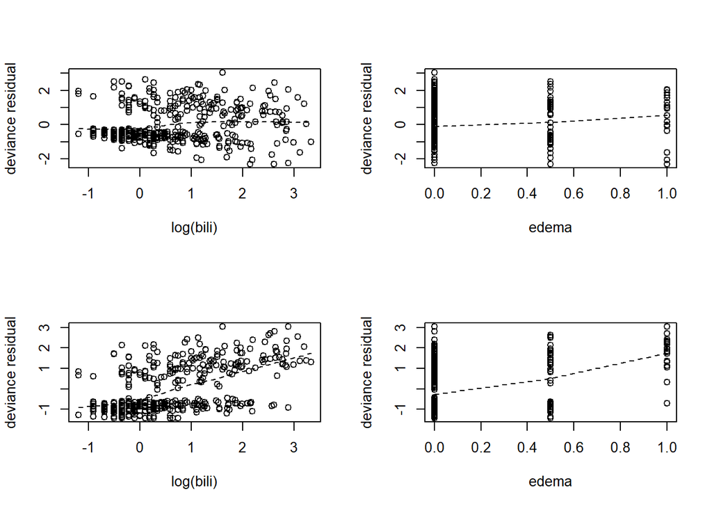

```r
r <- resid(fit,data=pbc,type="deviance")
par(mfrow=c(2,2))
plot(log(bili),r,xlab="log(bili)",ylab="deviance residual")
lines(lowess(log(bili),r,iter=0),lty=2)
plot(edema,r,xlab="edema",ylab="deviance residual")
lines(lowess(edema,r,iter=0),lty=2)
plot(log(bili),r1,xlab="log(bili)",ylab="deviance residual")
lines(lowess(log(bili),r1,iter=0),lty=2)
plot(edema,r1,xlab="edema",ylab="deviance residual")
lines(lowess(edema,r1,iter=0),lty=2)
```

```r
par(mfrow=c(1,1))
```

#### 변수 log(bili), edema를 포함한 Cox 모형 적합 후 패턴변화가 줄어듬.

```r
# albumin, log(protime)
fit <- coxph(Surv(time,censor)~albumin+log(protime),data=pbc)
summary(fit)
```

```
## Call:
## coxph(formula = Surv(time, censor) ~ albumin + log(protime),
##     data = pbc)
##
##   n= 416, number of events= 160
##    (2 observations deleted due to missingness)
##
##                 coef exp(coef) se(coef)      z Pr(>|z|)
## albumin      -1.4377    0.2375   0.1875 -7.667 1.77e-14 ***
## log(protime)  3.1576   23.5152   0.5900  5.352 8.71e-08 ***
## ---
## Signif. codes:  0 '***' 0.001 '**' 0.01 '*' 0.05 '.' 0.1 ' ' 1
##
##              exp(coef) exp(-coef) lower .95 upper .95
## albumin         0.2375    4.21090    0.1644     0.343
## log(protime)   23.5152    0.04253    7.3980    74.745
##
## Concordance= 0.742  (se = 0.022 )
## Likelihood ratio test= 86.75  on 2 df,   p=<2e-16
## Wald test            = 101.5  on 2 df,   p=<2e-16
## Score (logrank) test = 106.2  on 2 df,   p=<2e-16
```

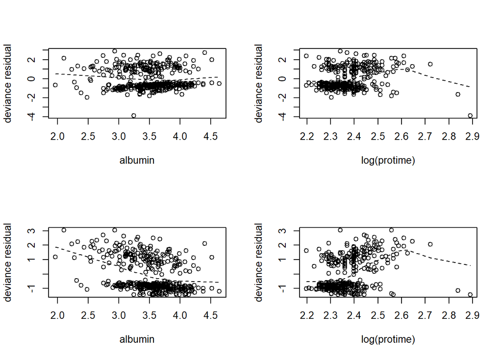

```r
r <- resid(fit,data=pbc,type="deviance")
par(mfrow=c(2,2))
plot(albumin[is.na(log(protime))!=TRUE],r,xlab="albumin",ylab="deviance residual")
lines(lowess(albumin[is.na(log(protime))!=TRUE],r,iter=0),lty=2)
plot(log(protime)[is.na(log(protime))!=TRUE],r,xlab="log(protime)",ylab="deviance residual")
lines(lowess(log(protime)[is.na(log(protime))!=TRUE],r,iter=0),lty=2)
plot(albumin[is.na(log(protime))!=TRUE],r1[is.na(log(protime))!=TRUE],xlab="albumin",ylab="deviance residual")
lines(lowess(albumin[is.na(log(protime))!=TRUE],r1[is.na(log(protime))!=TRUE],iter=0),lty=2)
plot(log(protime)[is.na(log(protime))!=TRUE],r1[is.na(log(protime))!=TRUE],xlab="log(protime)",ylab="deviance residual")
lines(lowess(log(protime)[is.na(log(protime))!=TRUE],r1[is.na(log(protime))!=TRUE],iter=0),lty=2)
```

```r
par(mfrow=c(1,1))
```

#### 변수 albumin, log(protime)을 포함한 Cox 모형 적합 후 패턴변화가 줄어듬.

```r
# albumin, edema
fit <- coxph(Surv(time,censor)~albumin+edema,data=pbc)
summary(fit)
```

```
## Call:
## coxph(formula = Surv(time, censor) ~ albumin + edema, data = pbc)
##
##   n= 418, number of events= 161
##
##            coef exp(coef) se(coef)      z Pr(>|z|)
## albumin -1.2338    0.2912   0.1942 -6.352 2.12e-10 ***
## edema    1.6581    5.2494   0.2580  6.427 1.30e-10 ***
## ---
## Signif. codes:  0 '***' 0.001 '**' 0.01 '*' 0.05 '.' 0.1 ' ' 1
##
##         exp(coef) exp(-coef) lower .95 upper .95
## albumin    0.2912     3.4343     0.199    0.4261
## edema      5.2494     0.1905     3.166    8.7039
##
## Concordance= 0.732  (se = 0.022 )
## Likelihood ratio test= 98.67  on 2 df,   p=<2e-16
## Wald test            = 125.5  on 2 df,   p=<2e-16
## Score (logrank) test = 142.7  on 2 df,   p=<2e-16
```

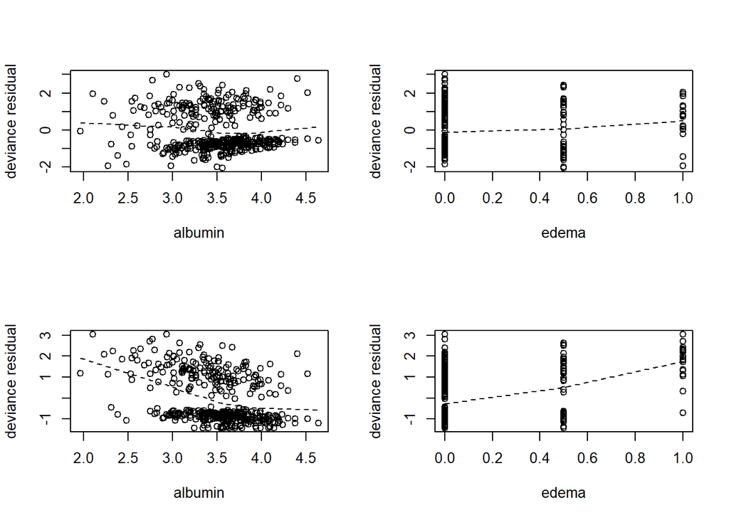

```r
r <- resid(fit,data=pbc,type="deviance")
par(mfrow=c(2,2))
plot(albumin,r,xlab="albumin",ylab="deviance residual")
lines(lowess(albumin,r,iter=0),lty=2)
plot(edema,r,xlab="edema",ylab="deviance residual")
lines(lowess(edema,r,iter=0),lty=2)
plot(albumin,r1,xlab="albumin",ylab="deviance residual")
lines(lowess(albumin,r1,iter=0),lty=2)
plot(edema,r1,xlab="edema",ylab="deviance residual")
lines(lowess(edema,r1,iter=0),lty=2)
```

```r
par(mfrow=c(1,1))
```

#### 변수 albumin, edema를 포함한 Cox 모형 적합 후 패턴변화가 줄어듬.

```r
# log(protime), edema
fit <- coxph(Surv(time,censor)~log(protime)+edema,data=pbc)
summary(fit)
```

```
## Call:
## coxph(formula = Surv(time, censor) ~ log(protime) + edema, data = pbc)
##
##   n= 416, number of events= 160
##    (2 observations deleted due to missingness)
##
##                 coef exp(coef) se(coef)     z Pr(>|z|)
## log(protime)  3.1763   23.9585   0.6628 4.793 1.65e-06 ***
## edema         1.9326    6.9074   0.2473 7.816 5.44e-15 ***
## ---
## Signif. codes:  0 '***' 0.001 '**' 0.01 '*' 0.05 '.' 0.1 ' ' 1
##
##              exp(coef) exp(-coef) lower .95 upper .95
## log(protime)    23.959    0.04174     6.536     87.82
## edema            6.907    0.14477     4.255     11.21
##
## Concordance= 0.731  (se = 0.023 )
## Likelihood ratio test= 79.75  on 2 df,   p=<2e-16
## Wald test            = 106  on 2 df,   p=<2e-16
## Score (logrank) test = 126.6  on 2 df,   p=<2e-16
```

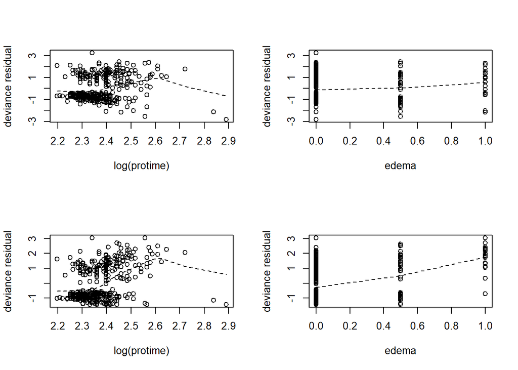

```r
r <- resid(fit,data=pbc,type="deviance")
par(mfrow=c(2,2))
plot(log(protime)[is.na(log(protime))!=TRUE],r,xlab="log(protime)",ylab="deviance residual")
lines(lowess(log(protime)[is.na(log(protime))!=TRUE],r,iter=0),lty=2)
plot(edema[is.na(log(protime))!=TRUE],r,xlab="edema",ylab="deviance residual")
lines(lowess(edema[is.na(log(protime))!=TRUE],r,iter=0),lty=2)
plot(log(protime)[is.na(log(protime))!=TRUE],r1[is.na(log(protime))!=TRUE],xlab="log(protime)",ylab="deviance residual")
lines(lowess(log(protime)[is.na(log(protime))!=TRUE],r1[is.na(log(protime))!=TRUE],iter=0),lty=2)
plot(edema[is.na(log(protime))!=TRUE],r1[is.na(log(protime))!=TRUE],xlab="edema",ylab="deviance residual")
lines(lowess(edema[is.na(log(protime))!=TRUE],r1[is.na(log(protime))!=TRUE],iter=0),lty=2)
```

```r
par(mfrow=c(1,1))
```

#### 변수 log(protime), edema를 포함한 Cox 모형 적합 후 패턴변화가 줄어듬.

### (7) 이산 공변량에 대해 비례성 검토를 해 보시오.

#### 사용 공변량 중 edema가 이산 공변량이므로 이에 대해 비례성 검토를 진행한다.

```r
library(KMsurv)
library(survminer)
fit <- survfit(coxph(Surv(time,censor)~strata(factor(edema)),data=pbc,method='breslow'))
summary(fit)
```

```
## Call: survfit(formula = coxph(Surv(time, censor) ~ strata(factor(edema)),
##     data = pbc, method = "breslow"))
##
##                 0
##  time n.risk n.event survival std.err lower 95% CI upper 95% CI
##    41    354       1    0.997 0.00282        0.992        1.000
##    43    353       1    0.994 0.00398        0.987        1.000
##   111    352       1    0.992 0.00487        0.982        1.000
##   186    351       1    0.989 0.00561        0.978        1.000
##   198    350       1    0.986 0.00626        0.974        0.998
##   207    349       1    0.983 0.00685        0.970        0.997
##   216    348       1    0.980 0.00739        0.966        0.995
##   221    347       1    0.977 0.00789        0.962        0.993
##   249    346       1    0.975 0.00835        0.958        0.991
##   304    345       1    0.972 0.00879        0.955        0.989
```

[output cut: 155 more lines]

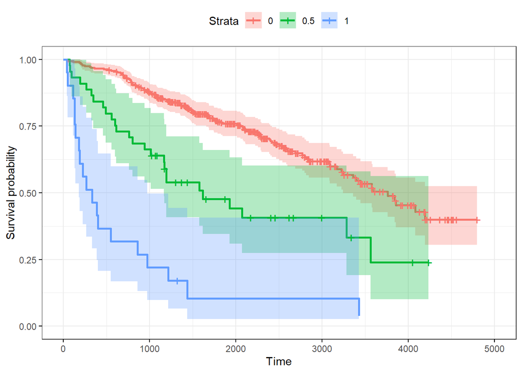

```r
ggsurvplot(fit,data=pbc,conf.int=TRUE,risk.table.col="strata",ggtheme=theme_bw())
```

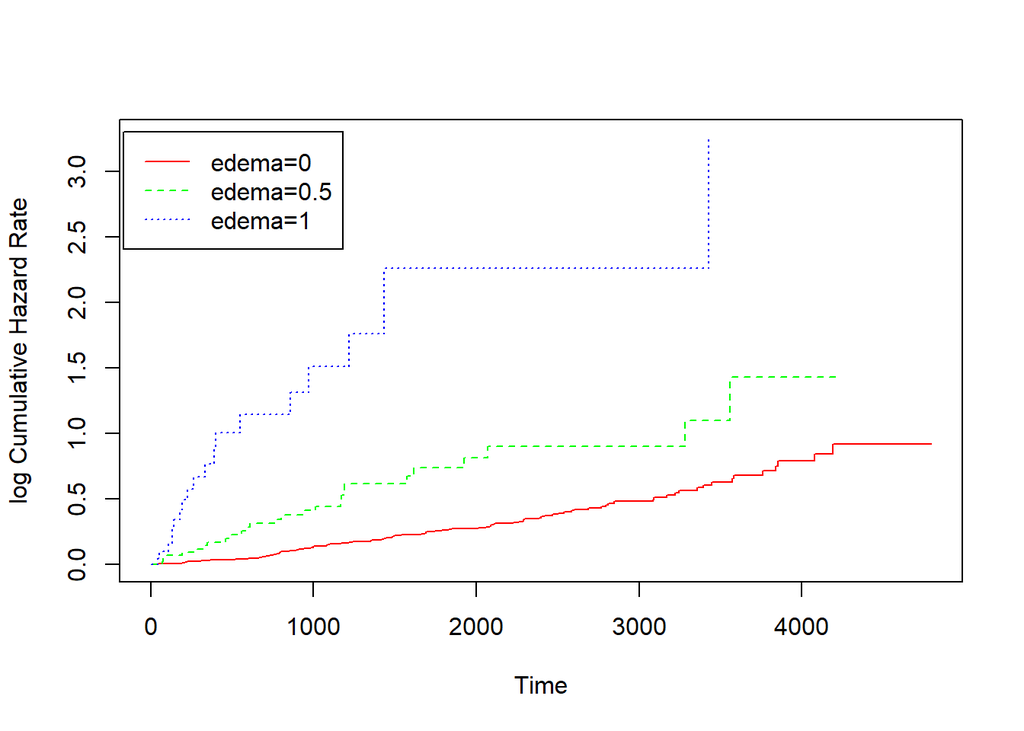

```r
plot(fit,fun='cumhaz',col=c('red','green','blue'),lty=c(1,2,3),xlab='Time',ylab='log Cumulative Hazard Rate')
legend(-170,3.3,legend=c('edema=0','edema=0.5','edema=1'),lty=c(1,2,3),col=c('red','green','blue'))
```

#### 검토결과 생존함수와 로그 누적기저위험함수 모두 선이 교차하지 않으므로 비례성 관계를 만족하고 있다고 판단된다.

### (8) 적절한 비례위험모형을 제안하고 잔차분석을 하시오.

#### (1) ~ (7) 의 결과를 통해 사용 공변량을 비례위험모형에 포함시켰을 때 패턴변화가 줄어들고 있고 이산 공변량인 edema의 경우 비례성 관계를 만족하고 있다고 판단된다. 이에 따라 5가지 공변량을 모두 포함한 모형을 적합해보고 잔차분석을 실시하도록 한다.

```r
fit0 <- coxph(Surv(time,censor)~1,data=pbc)
summary(fit0)
```

```
## Call:  coxph(formula = Surv(time, censor) ~ 1, data = pbc)
##
## Null model
##   log likelihood= -873.4721
##   n= 418
```

```r
r01 <- resid(fit0,data=pbc,type="martingale")
r02 <- resid(fit0,data=pbc,type="deviance")
fit <- coxph(Surv(time,censor)~age+log(bili)+albumin+log(protime)+edema,data=pbc)
summary(fit)
```

```
## Call:
## coxph(formula = Surv(time, censor) ~ age + log(bili) + albumin +
##     log(protime) + edema, data = pbc)
##
##   n= 416, number of events= 160
##    (2 observations deleted due to missingness)
##
##                   coef exp(coef)  se(coef)      z Pr(>|z|)
## age           0.039713  1.040512  0.007655  5.188 2.12e-07 ***
## log(bili)     0.862491  2.369054  0.083026 10.388  < 2e-16 ***
## albumin      -0.756712  0.469207  0.209116 -3.619 0.000296 ***
## log(protime)  2.373164 10.731297  0.767849  3.091 0.001997 **
## edema         0.902100  2.464774  0.271733  3.320 0.000901 ***
## ---
## Signif. codes:  0 '***' 0.001 '**' 0.01 '*' 0.05 '.' 0.1 ' ' 1
##
##              exp(coef) exp(-coef) lower .95 upper .95
## age             1.0405    0.96107    1.0250    1.0562
## log(bili)       2.3691    0.42211    2.0133    2.7877
## albumin         0.4692    2.13126    0.3114    0.7069
## log(protime)   10.7313    0.09319    2.3826   48.3333
## edema           2.4648    0.40572    1.4470    4.1983
##
## Concordance= 0.835  (se = 0.017 )
## Likelihood ratio test= 230.1  on 5 df,   p=<2e-16
## Wald test            = 232.6  on 5 df,   p=<2e-16
## Score (logrank) test = 299.1  on 5 df,   p=<2e-16
```

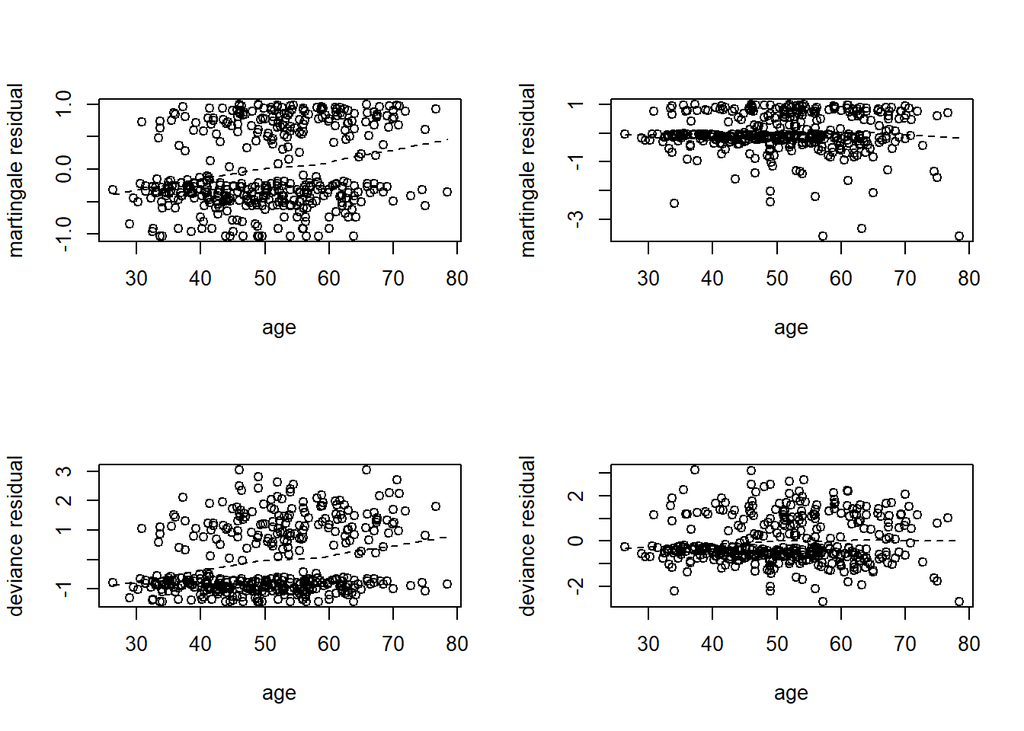

```r
r1 <- resid(fit,data=pbc,type="martingale")
r2 <- resid(fit,data=pbc,type="deviance")
par(mfrow=c(2,2))
# age
plot(age,r01,xlab="age",ylab="martingale residual")
lines(lowess(age,r01,iter=0),lty=2)
plot(age[is.na(log(protime))!=TRUE],r1,xlab="age",ylab="martingale residual")
lines(lowess(age[is.na(log(protime))!=TRUE],r1,iter=0),lty=2)
plot(age,r02,xlab="age",ylab="deviance residual")
lines(lowess(age,r02,iter=0),lty=2)
plot(age[is.na(log(protime))!=TRUE],r2,xlab="age",ylab="deviance residual")
lines(lowess(age[is.na(log(protime))!=TRUE],r2,iter=0),lty=2)
```

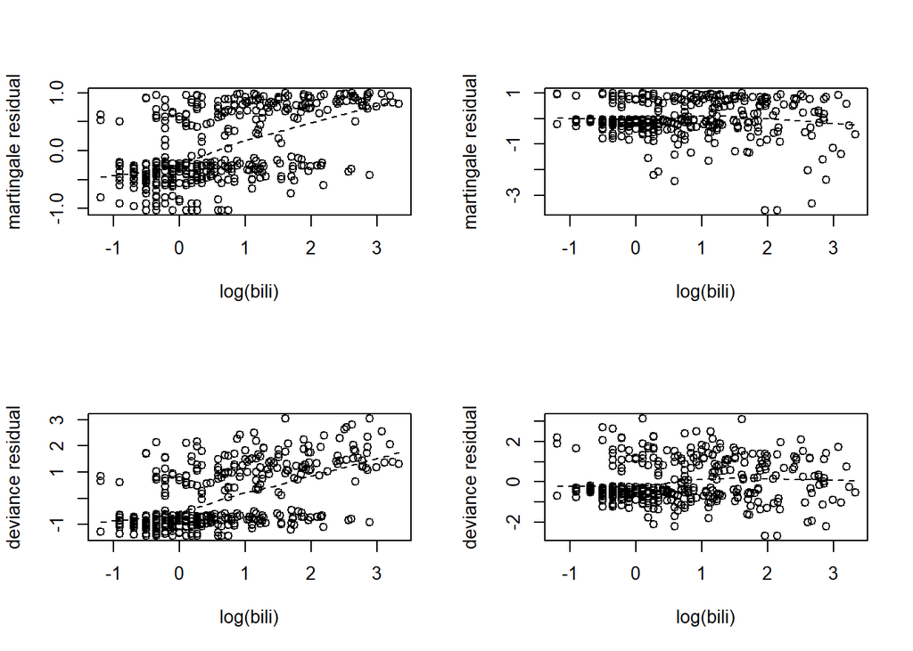

```r
# log(bili)
plot(log(bili),r01,xlab="log(bili)",ylab="martingale residual")
lines(lowess(log(bili),r01,iter=0),lty=2)
plot(log(bili)[is.na(log(protime))!=TRUE],r1,xlab="log(bili)",ylab="martingale residual")
lines(lowess(log(bili)[is.na(log(protime))!=TRUE],r1,iter=0),lty=2)
plot(log(bili),r02,xlab="log(bili)",ylab="deviance residual")
lines(lowess(log(bili),r02,iter=0),lty=2)
plot(log(bili)[is.na(log(protime))!=TRUE],r2,xlab="log(bili)",ylab="deviance residual")
lines(lowess(log(bili)[is.na(log(protime))!=TRUE],r2,iter=0),lty=2)
```

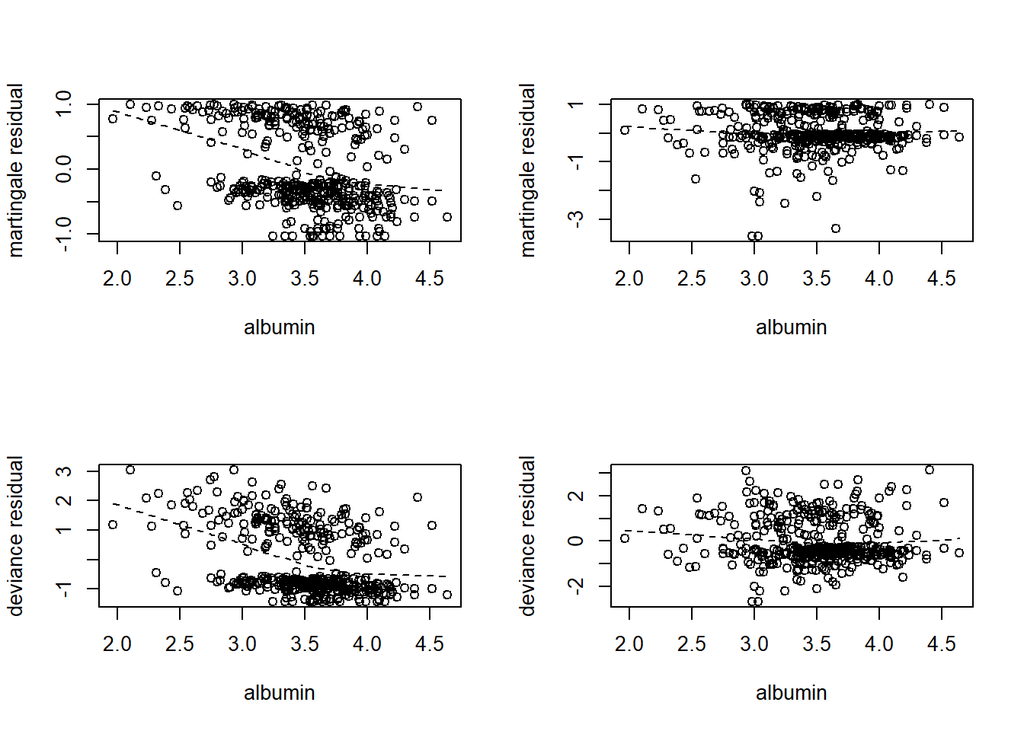

```r
# albumin
plot(albumin,r01,xlab="albumin",ylab="martingale residual")
lines(lowess(albumin,r01,iter=0),lty=2)
plot(albumin[is.na(log(protime))!=TRUE],r1,xlab="albumin",ylab="martingale residual")
lines(lowess(albumin[is.na(log(protime))!=TRUE],r1,iter=0),lty=2)
plot(albumin,r02,xlab="albumin",ylab="deviance residual")
lines(lowess(albumin,r02,iter=0),lty=2)
plot(albumin[is.na(log(protime))!=TRUE],r2,xlab="albumin",ylab="deviance residual")
lines(lowess(albumin[is.na(log(protime))!=TRUE],r2,iter=0),lty=2)
```

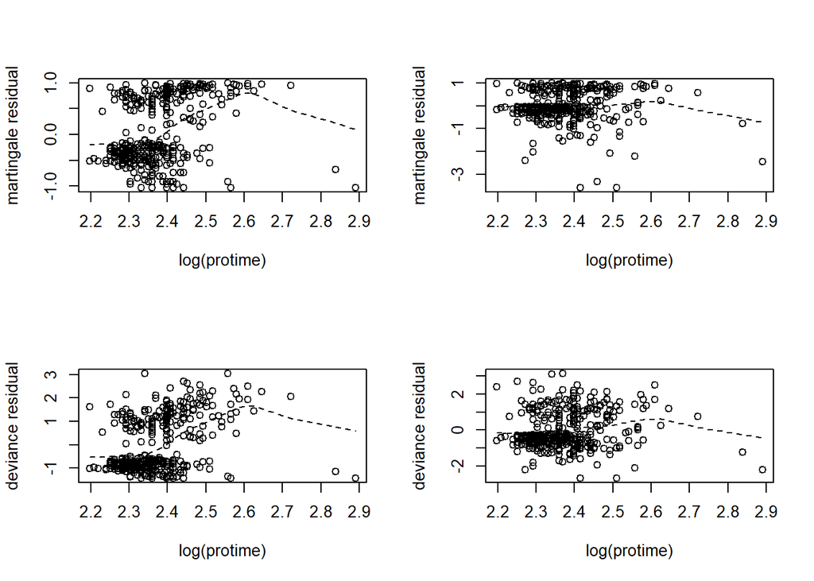

```r
# log(protime)
plot(log(protime)[is.na(log(protime))!=TRUE],r01[is.na(log(protime))!=TRUE],xlab="log(protime)",ylab="martingale residual")
lines(lowess(log(protime)[is.na(log(protime))!=TRUE],r01[is.na(log(protime))!=TRUE],iter=0),lty=2)
plot(log(protime)[is.na(log(protime))!=TRUE],r1,xlab="log(protime)",ylab="martingale residual")
lines(lowess(log(protime)[is.na(log(protime))!=TRUE],r1,iter=0),lty=2)
plot(log(protime)[is.na(log(protime))!=TRUE],r02[is.na(log(protime))!=TRUE],xlab="log(protime)",ylab="deviance residual")
lines(lowess(log(protime)[is.na(log(protime))!=TRUE],r02[is.na(log(protime))!=TRUE],iter=0),lty=2)
plot(log(protime)[is.na(log(protime))!=TRUE],r2,xlab="log(protime)",ylab="deviance residual")
lines(lowess(log(protime)[is.na(log(protime))!=TRUE],r2,iter=0),lty=2)
```

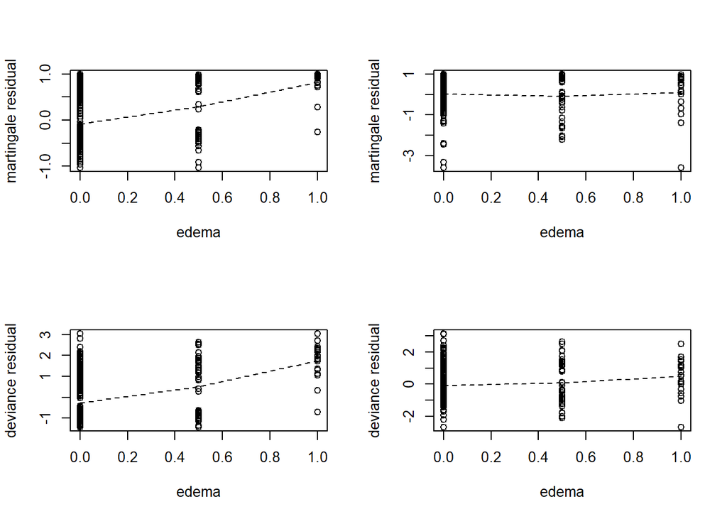

```r
# edema
plot(edema,r01,xlab="edema",ylab="martingale residual")
lines(lowess(edema,r01,iter=0),lty=2)
plot(edema[is.na(log(protime))!=TRUE],r1,xlab="edema",ylab="martingale residual")
lines(lowess(edema[is.na(log(protime))!=TRUE],r1,iter=0),lty=2)
plot(edema,r02,xlab="edema",ylab="deviance residual")
lines(lowess(edema,r02,iter=0),lty=2)
plot(edema[is.na(log(protime))!=TRUE],r2,xlab="edema",ylab="deviance residual")
lines(lowess(edema[is.na(log(protime))!=TRUE],r2,iter=0),lty=2)
```

```r
par(mfrow=c(1,1))
```

#### 모형적합 결과 모든 공변량이 유의하며, 5가지 공변량을 모두 포함했을 때 잔차의 패턴변화가 줄어듬을 확인할 수 있다.

```r
detach(pbc)
```

### 연습문제 8-2) 다음은 Hodgkin’s와 Non Hodgkin’s 림프종(lymphoma) 환자에 대한 데이터로 미국 오하이오 주에 있는 병원에서 골수이식을 한 환자 데이터이다.

```r
library(KMsurv)
data(hodg)
head(hodg)
```

```
##   gtype dtype time delta score wtime
## 1     1     1   28     1    90    24
## 2     1     1   32     1    30     7
## 3     1     1   49     1    40     8
## 4     1     1   84     1    60    10
## 5     1     1  357     1    70    42
## 6     1     1  933     0    90     9
```

```r
attach(hodg)
```

## 포함된 변수는 다음과 같다.

### gtype : Graft type (1=allogenic, 2=autologous)

### dtype : Disease type (1=Non Hodgkin lymphoma, 2=Hodgkins disease)

### time : Time to death or relapse, days

### dalta : Death/relapse indicator (0=alive, 1=dead)

### score : Karnofsky score

### wtime : Waiting time to transplant in months

### (1) 공변량 gtype에 대해 비례성을 검토하시오.

```r
library(KMsurv)
library(survminer)
fit <- survfit(coxph(Surv(time,delta)~strata(factor(gtype)),data=hodg,method='breslow'))
summary(fit)
```

```
## Call: survfit(formula = coxph(Surv(time, delta) ~ strata(factor(gtype)),
##     data = hodg, method = "breslow"))
##
##                 1
##  time n.risk n.event survival std.err lower 95% CI upper 95% CI
##     2     16       1    0.939  0.0587        0.831        1.000
##     4     15       1    0.879  0.0803        0.735        1.000
##    28     14       1    0.818  0.0949        0.652        1.000
##    32     13       1    0.758  0.1054        0.577        0.995
##    49     12       1    0.697  0.1131        0.507        0.958
##    72     11       1    0.637  0.1184        0.442        0.916
##    77     10       1    0.576  0.1216        0.381        0.871
##    79      9       1    0.515  0.1230        0.323        0.823
##    84      8       1    0.455  0.1225        0.268        0.771
##   357      7       1    0.394  0.1202        0.217        0.717
```

[output cut: 18 more lines]

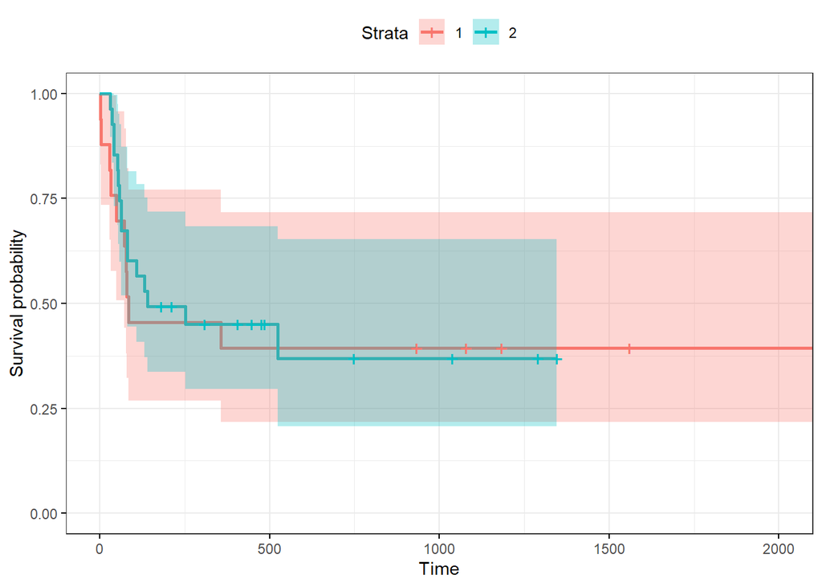

```r
ggsurvplot(fit,data=pbc,conf.int=TRUE,risk.table.col="strata",ggtheme=theme_bw())
```

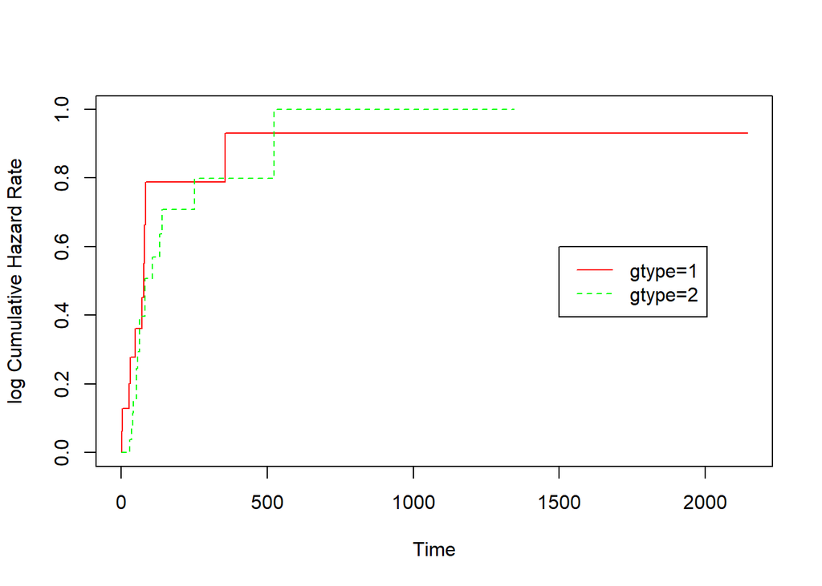

```r
plot(fit,fun='cumhaz',col=c('red','green'),lty=c(1,2),xlab='Time',ylab='log Cumulative Hazard Rate')
legend(1500,0.6,legend=c('gtype=1','gtype=2'),lty=c(1,2),col=c('red','green'))
```

#### 검토결과 생존함수와 로그 누적기저위험함수 모두 선이 교차하고 있으므로 비례성 관계를 만족하지 않아 보인다.

### (2) 공변량 dtype에 대해 비례성을 검토하시오.

```r
fit <- survfit(coxph(Surv(time,delta)~strata(factor(dtype)),data=hodg,method='breslow'))
summary(fit)
```

```
## Call: survfit(formula = coxph(Surv(time, delta) ~ strata(factor(dtype)),
##     data = hodg, method = "breslow"))
##
##                 1
##  time n.risk n.event survival std.err lower 95% CI upper 95% CI
##    28     23       1    0.957  0.0416        0.879        1.000
##    32     22       1    0.915  0.0575        0.809        1.000
##    42     21       1    0.872  0.0688        0.747        1.000
##    49     20       1    0.830  0.0775        0.691        0.997
##    53     19       1    0.787  0.0844        0.638        0.971
##    57     18       1    0.745  0.0899        0.588        0.944
##    63     17       1    0.702  0.0943        0.540        0.914
##    81     16       2    0.620  0.0996        0.452        0.849
##    84     14       1    0.577  0.1015        0.409        0.815
##   140     13       1    0.534  0.1026        0.367        0.778
```

[output cut: 18 more lines]

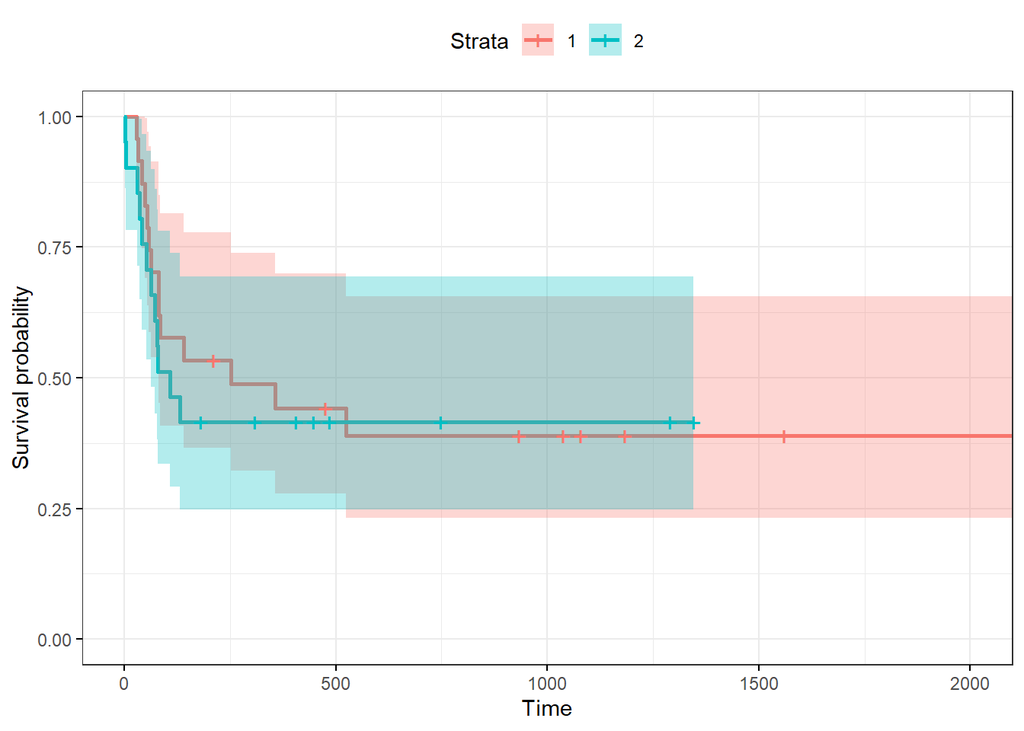

```r
ggsurvplot(fit,data=pbc,conf.int=TRUE,risk.table.col="strata",ggtheme=theme_bw())
```

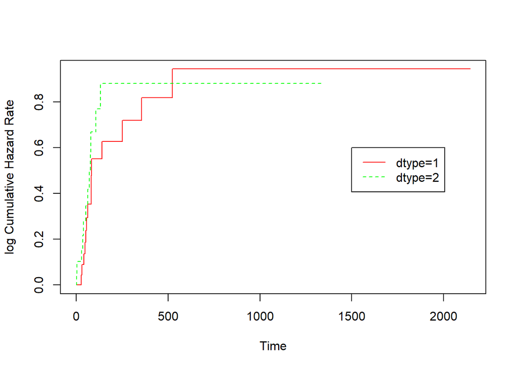

```r
plot(fit,fun='cumhaz',col=c('red','green'),lty=c(1,2),xlab='Time',ylab='log Cumulative Hazard Rate')
legend(1500,0.6,legend=c('dtype=1','dtype=2'),lty=c(1,2),col=c('red','green'))
```

#### 검토결과 생존함수와 로그 누적기저위험함수 모두 선이 교차하고 있으므로 비례성 관계를 만족하지 않아 보인다.

### (3) 공변량이 없는 모형에서 마팅게일 잔차를 구하고 잔차그림을 그리시오.

```r
attach(hodg)
Surv(time,delta)
```

```
##  [1]   28    32    49    84   357   933+ 1078+ 1183+ 1560+ 2114+ 2144+    2
## [13]    4    72    77    79    42    53    57    63    81   140    81   252
## [25]  524   210+  476+ 1037+   30    36    41    52    62   108   132   180+
## [37]  307+  406+  446+  484+  748+ 1290+ 1345+
```

```r
fit0 <- coxph(Surv(time,delta)~1,data=hodg)
summary(fit0)
```

```
## Call:  coxph(formula = Surv(time, delta) ~ 1, data = hodg)
##
## Null model
##   log likelihood= -87.25832
##   n= 43
```

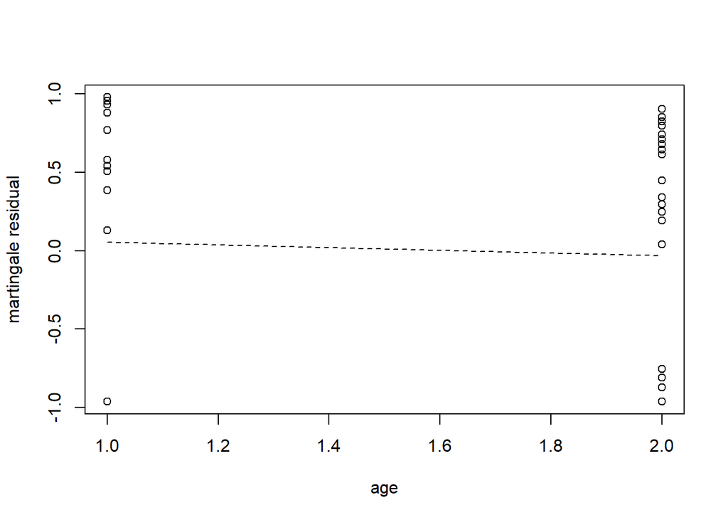

```r
r1 <- resid(fit0,data=hodg,type="martingale")
plot(gtype,r1,xlab="age",ylab="martingale residual")
lines(lowess(gtype,r1,iter=0),lty=2)
```

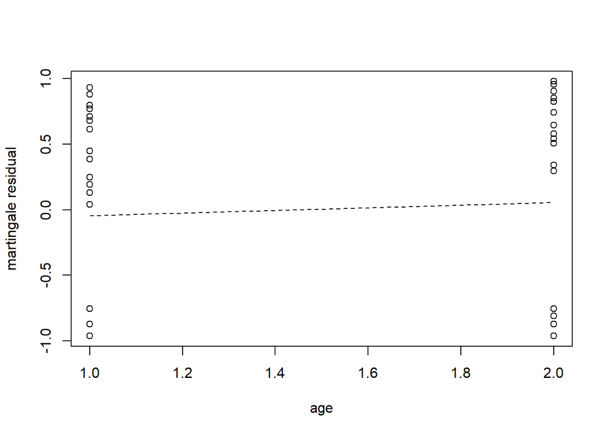

```r
plot(dtype,r1,xlab="age",ylab="martingale residual")
lines(lowess(dtype,r1,iter=0),lty=2)
```

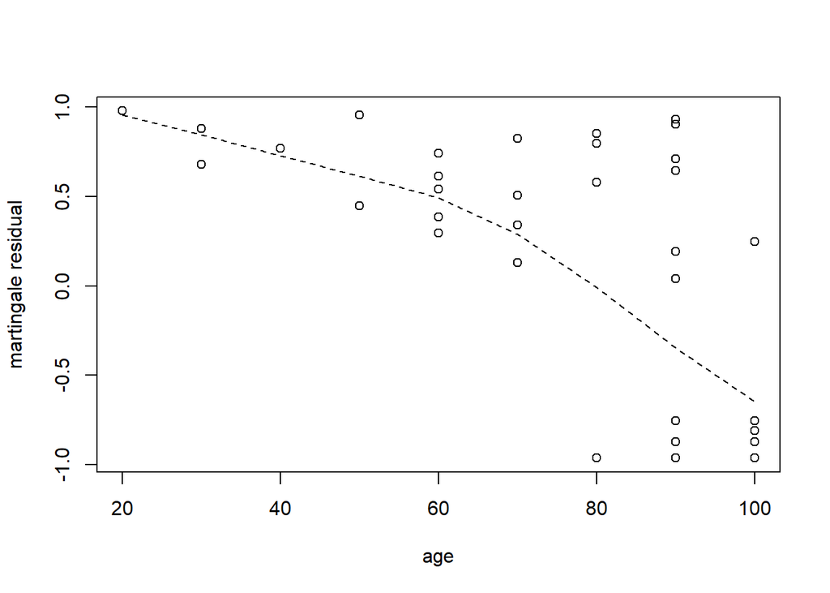

```r
plot(score,r1,xlab="age",ylab="martingale residual")
lines(lowess(score,r1,iter=0),lty=2)
```

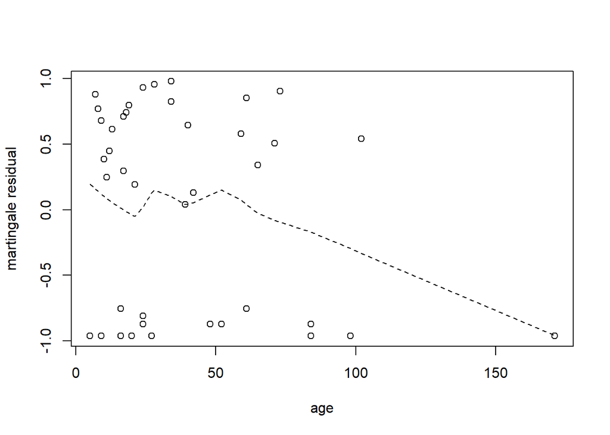

```r
plot(wtime,r1,xlab="age",ylab="martingale residual")
lines(lowess(wtime,r1,iter=0),lty=2)
```

### (4) 공변량 gtype이 있는 비례위험모형을 적합하고 마팅게일 잔차그림을 그리고 해석하시오.

```r
fit1 <- coxph(Surv(time,delta)~gtype,data=hodg)
summary(fit1)
```

```
## Call:
## coxph(formula = Surv(time, delta) ~ gtype, data = hodg)
##
##   n= 43, number of events= 26
##
##          coef exp(coef) se(coef)      z Pr(>|z|)
## gtype -0.1461    0.8640   0.4052 -0.361    0.718
##
##       exp(coef) exp(-coef) lower .95 upper .95
## gtype     0.864      1.157    0.3905     1.912
##
## Concordance= 0.536  (se = 0.052 )
## Likelihood ratio test= 0.13  on 1 df,   p=0.7
## Wald test            = 0.13  on 1 df,   p=0.7
## Score (logrank) test = 0.13  on 1 df,   p=0.7
```

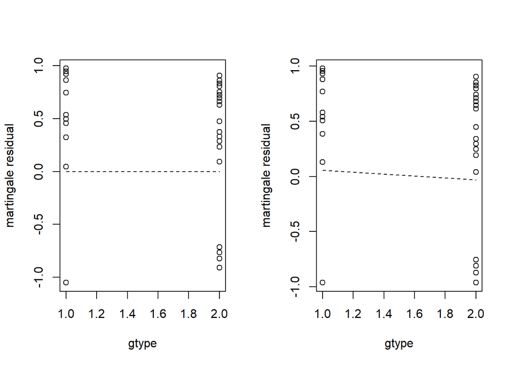

```r
r11 <- resid(fit1,data=hodg,type="martingale")
par(mfrow=c(1,2))
plot(gtype,r11,xlab="gtype",ylab="martingale residual")
lines(lowess(gtype,r11,iter=0),lty=2)
plot(gtype,r1,xlab="gtype",ylab="martingale residual")
lines(lowess(gtype,r1,iter=0),lty=2)
```

```r
par(mfrow=c(1,1))
```

#### 변수 gtype을 추가하여 비례위험모형을 적합하면 잔차의 선형성이 제거됨을 확인할 수 있다.

### (5) 공변량 dtype이 있는 비례위험모형을 적합하고 마팅게일 잔차그림을 그리고 해석하시오.

```r
fit2 <- coxph(Surv(time,delta)~dtype,data=hodg)
summary(fit2)
```

```
## Call:
## coxph(formula = Surv(time, delta) ~ dtype, data = hodg)
##
##   n= 43, number of events= 26
##
##         coef exp(coef) se(coef)     z Pr(>|z|)
## dtype 0.1724    1.1882   0.3946 0.437    0.662
##
##       exp(coef) exp(-coef) lower .95 upper .95
## dtype     1.188     0.8416    0.5483     2.575
##
## Concordance= 0.54  (se = 0.051 )
## Likelihood ratio test= 0.19  on 1 df,   p=0.7
## Wald test            = 0.19  on 1 df,   p=0.7
## Score (logrank) test = 0.19  on 1 df,   p=0.7
```

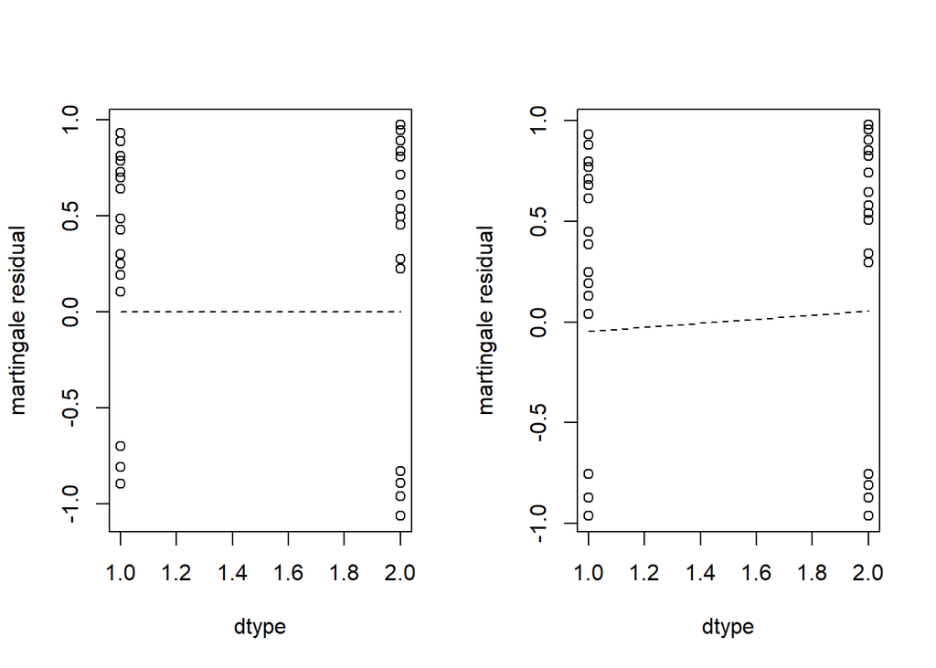

```r
r21 <- resid(fit2,data=hodg,type="martingale")
par(mfrow=c(1,2))
plot(dtype,r21,xlab="dtype",ylab="martingale residual")
lines(lowess(dtype,r21,iter=0),lty=2)
plot(dtype,r1,xlab="dtype",ylab="martingale residual")
lines(lowess(dtype,r1,iter=0),lty=2)
```

```r
par(mfrow=c(1,1))
```

#### 변수 dtype을 추가하여 비례위험모형을 적합하면 잔차의 선형성이 제거됨을을 확인할 수 있다.

### (6) 공변량들을 이용하여 적절한 비례위험모형을 적합하고 잔차분석을 하시오.

#### AIC(Akaike’s Information Criterion) 기준 stepwise variable selection을 통해 다음과 같이 변수를 선택해볼 수 있다.

```r
library(MASS)
fit <- coxph(Surv(time,delta)~gtype+dtype+score+wtime,data=hodg)
fit.step <- stepAIC(fit,trace=TRUE)
```

```
## Start:  AIC=155.8
## Surv(time, delta) ~ gtype + dtype + score + wtime
##
##         Df    AIC
## - gtype  1 154.07
## - wtime  1 154.89
## <none>     155.80
## - dtype  1 157.26
## - score  1 177.06
##
## Step:  AIC=154.07
## Surv(time, delta) ~ dtype + score + wtime
##
##         Df    AIC
## - wtime  1 153.03
## <none>     154.07
## - dtype  1 155.26
## - score  1 175.38
##
## Step:  AIC=153.03
## Surv(time, delta) ~ dtype + score
##
##         Df    AIC
## <none>     153.03
## - dtype  1 153.26
## - score  1 176.33
```

```r
summary(fit.step)
```

```
## Call:
## coxph(formula = Surv(time, delta) ~ dtype + score, data = hodg)
##
##   n= 43, number of events= 26
##
##           coef exp(coef) se(coef)      z Pr(>|z|)
## dtype  0.63423   1.88557  0.42223  1.502    0.133
## score -0.05804   0.94361  0.01194 -4.861 1.17e-06 ***
## ---
## Signif. codes:  0 '***' 0.001 '**' 0.01 '*' 0.05 '.' 0.1 ' ' 1
##
##       exp(coef) exp(-coef) lower .95 upper .95
## dtype    1.8856     0.5303    0.8242     4.314
## score    0.9436     1.0598    0.9218     0.966
##
## Concordance= 0.735  (se = 0.052 )
## Likelihood ratio test= 25.49  on 2 df,   p=3e-06
## Wald test            = 23.64  on 2 df,   p=7e-06
## Score (logrank) test = 29.83  on 2 df,   p=3e-07
```

```r
extractAIC(fit.step)
```

```
## [1]   2.0000 153.0314
```

#### AIC 기준에 의해 선택된 변수는 dtype, score이며 이때의 AIC 값은 153.0314이다. 이 모형에 대해 잔차분석을 실시하면 다음과 같다.

```r
fit3 <- coxph(Surv(time,delta)~dtype+score,data=hodg)
summary(fit3)
```

```
## Call:
## coxph(formula = Surv(time, delta) ~ dtype + score, data = hodg)
##
##   n= 43, number of events= 26
##
##           coef exp(coef) se(coef)      z Pr(>|z|)
## dtype  0.63423   1.88557  0.42223  1.502    0.133
## score -0.05804   0.94361  0.01194 -4.861 1.17e-06 ***
## ---
## Signif. codes:  0 '***' 0.001 '**' 0.01 '*' 0.05 '.' 0.1 ' ' 1
##
##       exp(coef) exp(-coef) lower .95 upper .95
## dtype    1.8856     0.5303    0.8242     4.314
## score    0.9436     1.0598    0.9218     0.966
##
## Concordance= 0.735  (se = 0.052 )
## Likelihood ratio test= 25.49  on 2 df,   p=3e-06
## Wald test            = 23.64  on 2 df,   p=7e-06
## Score (logrank) test = 29.83  on 2 df,   p=3e-07
```

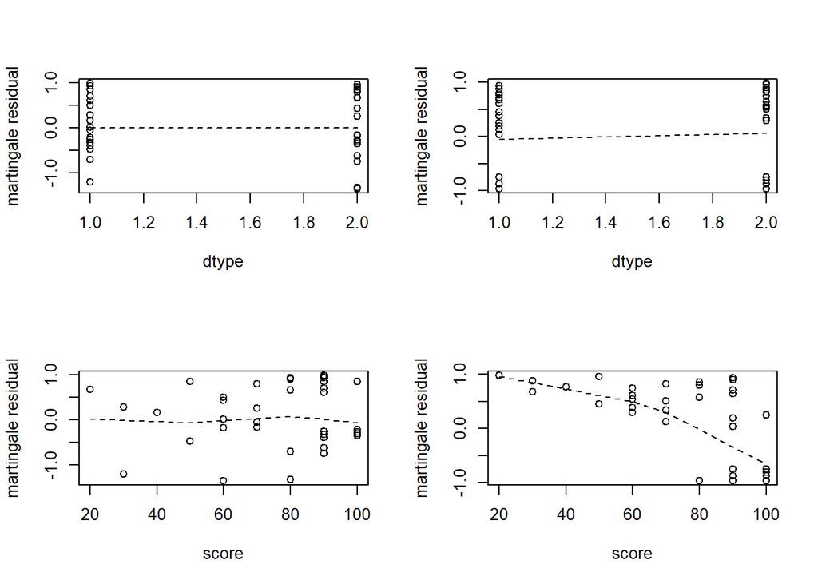

```r
r31 <- resid(fit3,data=hodg,type="martingale")
par(mfrow=c(2,2))
plot(dtype,r31,xlab="dtype",ylab="martingale residual")
lines(lowess(dtype,r31,iter=0),lty=2)
plot(dtype,r1,xlab="dtype",ylab="martingale residual")
lines(lowess(dtype,r1,iter=0),lty=2)
plot(score,r31,xlab="score",ylab="martingale residual")
lines(lowess(score,r31,iter=0),lty=2)
plot(score,r1,xlab="score",ylab="martingale residual")
lines(lowess(score,r1,iter=0),lty=2)
```

```r
par(mfrow=c(1,1))
```

#### 분석결과 공변량이 없는 모형과 비교하였을 때 잔차의 선형성이 제거됨을을 확인할 수 있다.